# Mangahas_Assignment2

# 2= Exploring categorical variable (continent) and quantitative variable(pop)

```r
Gapminder_Con_Pop <-gapminder %>%
  select(continent,pop)
```

#Number of entries from each continent (summary)

```r
summary(Gapminder_Con_Pop$continent, digits=1)
```

```
##   Africa Americas     Asia   Europe  Oceania
##      624      300      396      360       24
```

#Number of entries from each continent (table)

```r
Gapminder_Con_Pop %>%
  count(continent)
```

```
## # A tibble: 5 x 2
##   continent     n
##   <fct>     <int>
## 1 Africa      624
## 2 Americas    300
## 3 Asia        396
## 4 Europe      360
## 5 Oceania      24
```

#Maximum ppulation values for each of the 5 continents

```r
Gapminder_Con_Pop %>%
  group_by(continent) %>%
  summarise(max(pop))
```

```
## # A tibble: 5 x 2
##   continent `max(pop)`
##   <fct>          <int>
## 1 Africa     135031164
## 2 Americas   301139947
## 3 Asia      1318683096
## 4 Europe      82400996
## 5 Oceania     20434176
```

#Minimum population values for each of the 5 continents

```r
Gapminder_Con_Pop %>%
  group_by(continent) %>%
  summarise(min(pop))
```

```
## # A tibble: 5 x 2
##   continent `min(pop)`
##   <fct>          <int>
## 1 Africa         60011
## 2 Americas      662850
## 3 Asia          120447
## 4 Europe        147962
## 5 Oceania      1994794
```

#In summary, there are 5 continents with differing number of entries, and each of them has a wide range of populations over time.

#Finding the mean population in the gapminder dataset for each continent

```r
Gapminder_Con_Pop_Avg <-gapminder %>%
  group_by(continent) %>%
  summarise(average=mean(pop))
```

#Creating a column graph displaying results

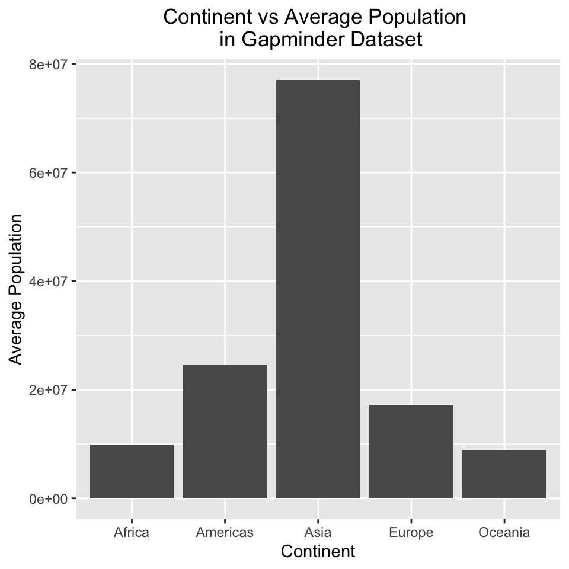

```r
ggplot(Gapminder_Con_Pop_Avg, aes(continent, average)) +
  geom_col()+
  xlab("Continent")+
  ylab("Average Population")+
  ggtitle("Continent vs Average Population \n in Gapminder Dataset") +
    theme(plot.title = element_text(hjust = 0.5))
```

# 3= Exploring various plot types

#Found a new dataset to look at through ‘R Datasets Package’ called rock, n=48

```r
library(rock)
```

#First ggplot (scatterplot) of 2 quantitative variables (area, perimeter)

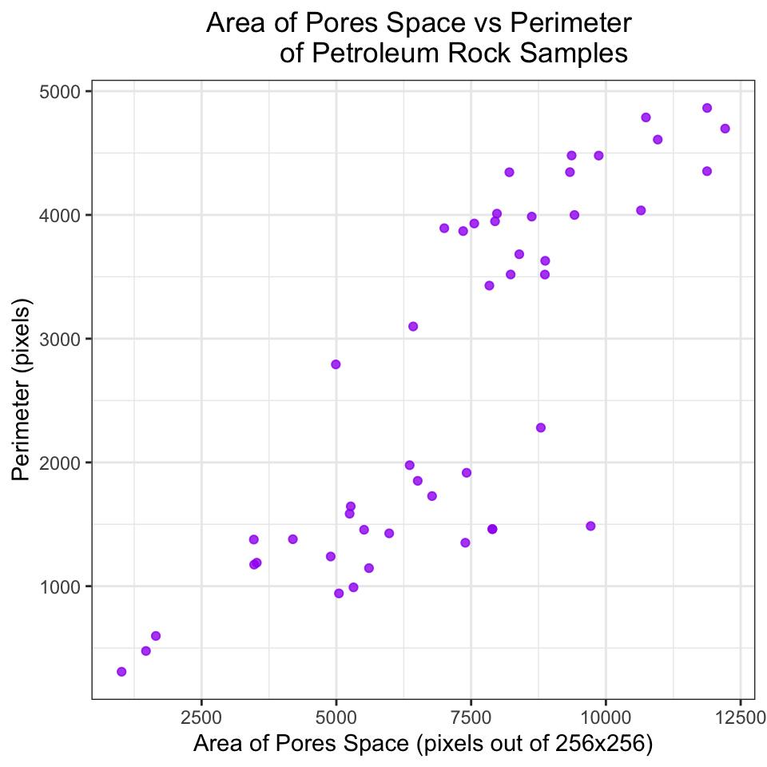

```r
ggplot(rock, aes(area, peri)) +
  geom_point(colour='purple', alpha=0.8) +
  theme_bw() +
  xlab('Area of Pores Space (pixels out of 256x256)')+
  ylab('Perimeter (pixels)') +
  ggtitle("Area of Pores Space vs Perimeter
        of Petroleum Rock Samples") +
    theme(plot.title = element_text(hjust = 0.5))
```

#Second ggplot (smooth) of 2 quantitative variables (area, perimeter)

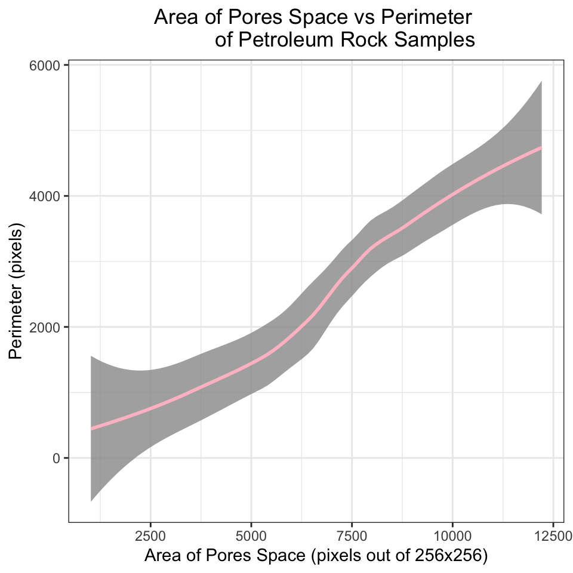

```r
ggplot(rock, aes(area, peri)) +
  geom_smooth(colour='pink', alpha=0.8) +
  theme_bw() +
  xlab('Area of Pores Space (pixels out of 256x256)')+
  ylab('Perimeter (pixels)') +
  ggtitle("Area of Pores Space vs Perimeter
          of Petroleum Rock Samples") +
    theme(plot.title = element_text(hjust = 0.5))
```

# Recycling (Optional) (extra 2%)

```r
filter(gapminder, country == c("Rwanda", "Afghanistan"))
```

```
## # A tibble: 12 x 6
##    country     continent  year lifeExp      pop gdpPercap
##    <fct>       <fct>     <int>   <dbl>    <int>     <dbl>
##  1 Afghanistan Asia       1957    30.3  9240934      821.
##  2 Afghanistan Asia       1967    34.0 11537966      836.
##  3 Afghanistan Asia       1977    38.4 14880372      786.
##  4 Afghanistan Asia       1987    40.8 13867957      852.
##  5 Afghanistan Asia       1997    41.8 22227415      635.
##  6 Afghanistan Asia       2007    43.8 31889923      975.
##  7 Rwanda      Africa     1952    40    2534927      493.
##  8 Rwanda      Africa     1962    43    3051242      597.
##  9 Rwanda      Africa     1972    44.6  3992121      591.
## 10 Rwanda      Africa     1982    46.2  5507565      882.
## 11 Rwanda      Africa     1992    23.6  7290203      737.
## 12 Rwanda      Africa     2002    43.4  7852401      786.
```

#No, they did not succeed as not all of the data for Afghanistan and Rwanda is being displayed. It seems that it is only showing data from each decade.

#Correct way to do this

```r
gapminder %>%
  filter (country=='Rwanda' | country== 'Afghanistan')
```

```
## # A tibble: 24 x 6
##    country     continent  year lifeExp      pop gdpPercap
##    <fct>       <fct>     <int>   <dbl>    <int>     <dbl>
##  1 Afghanistan Asia       1952    28.8  8425333      779.
##  2 Afghanistan Asia       1957    30.3  9240934      821.
##  3 Afghanistan Asia       1962    32.0 10267083      853.
##  4 Afghanistan Asia       1967    34.0 11537966      836.
##  5 Afghanistan Asia       1972    36.1 13079460      740.
##  6 Afghanistan Asia       1977    38.4 14880372      786.
##  7 Afghanistan Asia       1982    39.9 12881816      978.
##  8 Afghanistan Asia       1987    40.8 13867957      852.
##  9 Afghanistan Asia       1992    41.7 16317921      649.
## 10 Afghanistan Asia       1997    41.8 22227415      635.
## # … with 14 more rows
```

# Tibble display(Optional) (extra 1%)

```r
DT::datatable(gapminder)
```

|  | country | continent | year | lifeExp | pop | gdpPercap |
| --- | --- | --- | --- | --- | --- | --- |
| 1 | Afghanistan | Asia | 1952 | 28.801 | 8425333 | 779.4453145 |
| 2 | Afghanistan | Asia | 1957 | 30.332 | 9240934 | 820.8530296 |
| 3 | Afghanistan | Asia | 1962 | 31.997 | 10267083 | 853.10071 |
| 4 | Afghanistan | Asia | 1967 | 34.02 | 11537966 | 836.1971382 |
| 5 | Afghanistan | Asia | 1972 | 36.088 | 13079460 | 739.9811058 |
| 6 | Afghanistan | Asia | 1977 | 38.438 | 14880372 | 786.11336 |
| 7 | Afghanistan | Asia | 1982 | 39.854 | 12881816 | 978.0114388 |
| 8 | Afghanistan | Asia | 1987 | 40.822 | 13867957 | 852.3959448 |
| 9 | Afghanistan | Asia | 1992 | 41.674 | 16317921 | 649.3413952 |
| 10 | Afghanistan | Asia | 1997 | 41.763 | 22227415 | 635.341351 |

[output cut: 1694 more lines]